# Formulaire de réponse pour le test 2

**Alexandre Duhamel, Azmatally Rayan, Théo Deniel -> Groupe n°7**

## Partie I

### Question 1

- Charger le tableau de données dans R en utilisant la commande $x<- scan("sinistres.csv")$. Les montants des sinistres sont notés $x_1, ... , x_n$. On supposera que ce sont des réalisations de variables aléatoires $X_1, ... , X_n$ indépendantes et de même loi. A l’aide d’histogrammes et de graphes de probabilités, montrer que les lois normale et exponentielle ne sont pas des modèles plausibles pour modéliser les montants des sinistres.

#### Réponse :

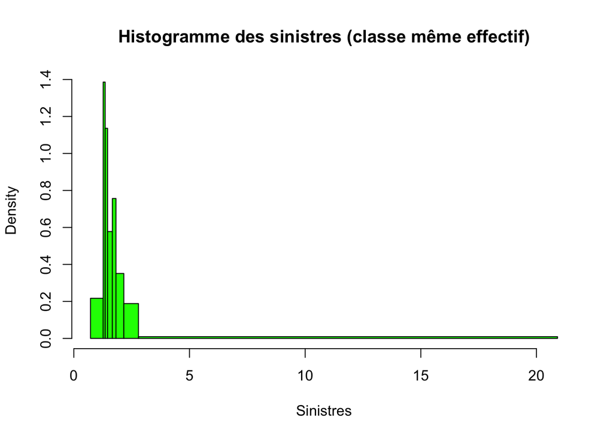

```r
#entrées
sinsitres <- scan("sinistres.csv")
s <- sort(sinsitres)
n <- length(sinsitres)

#trace historgramme même largeur, denisté loi exponentielle et denisté loi normale
a0 <- min(s)-0.025*(max(s)-min(s))
ak <- max(s)+0.025*(max(s)-min(s))
k <- 1 + log2(n)
bornes <- c(a0, quantile(s, seq(1, k-1) / k), ak)
hist(s,breaks=bornes, col='green',main="Histogramme des sinistres (classe même effectif)" , xlab="Sinistres")
```

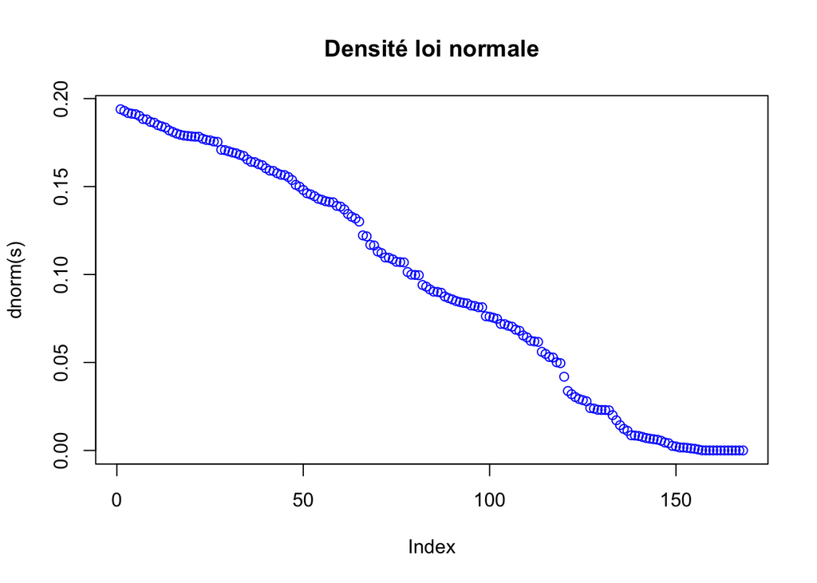

```r
plot(dnorm(s),col='blue',main='Densité loi normale')
```

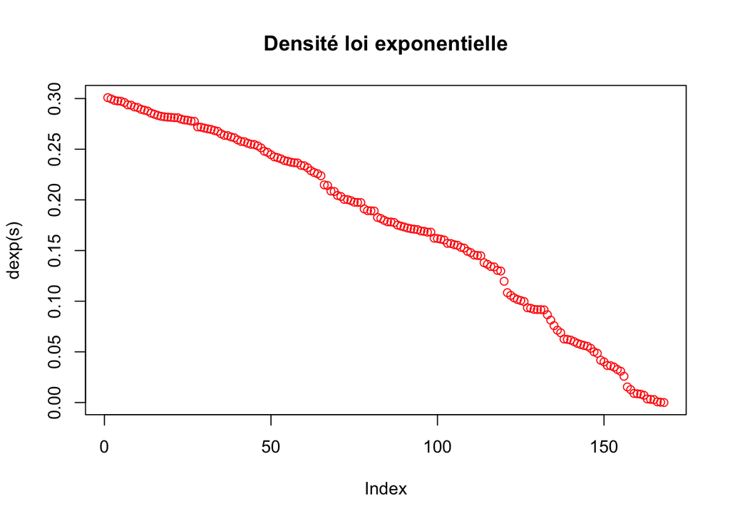

```r
plot(dexp(s),col='red',main='Densité loi exponentielle')
```

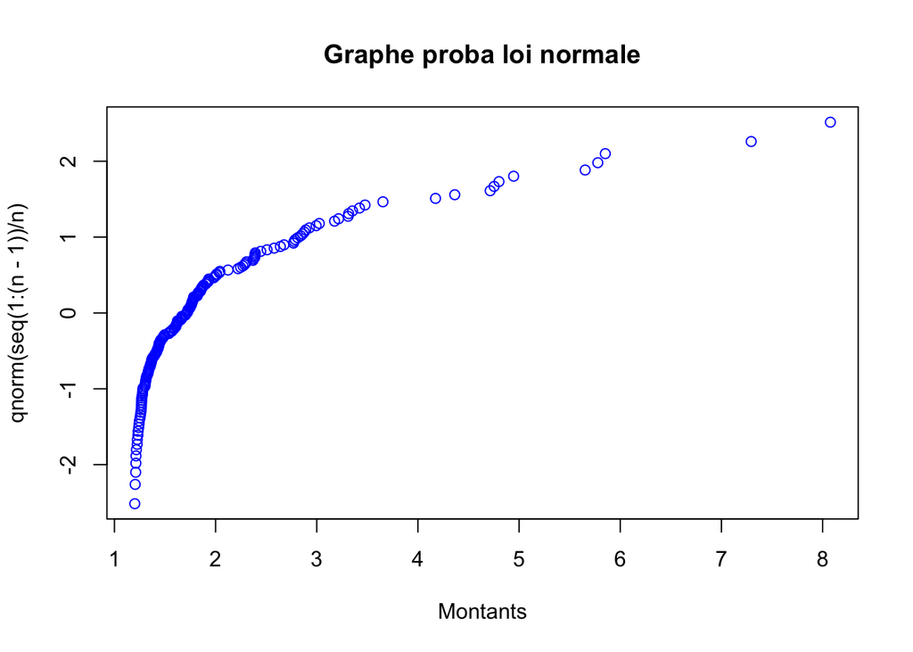

```r
#LOI NORMALE : graphe de proba pour loi normale
plot(s[1:(n-1)], qnorm(seq(1:(n-1))/n),main='Graphe proba loi normale',col='blue', xlab="Montants")
```

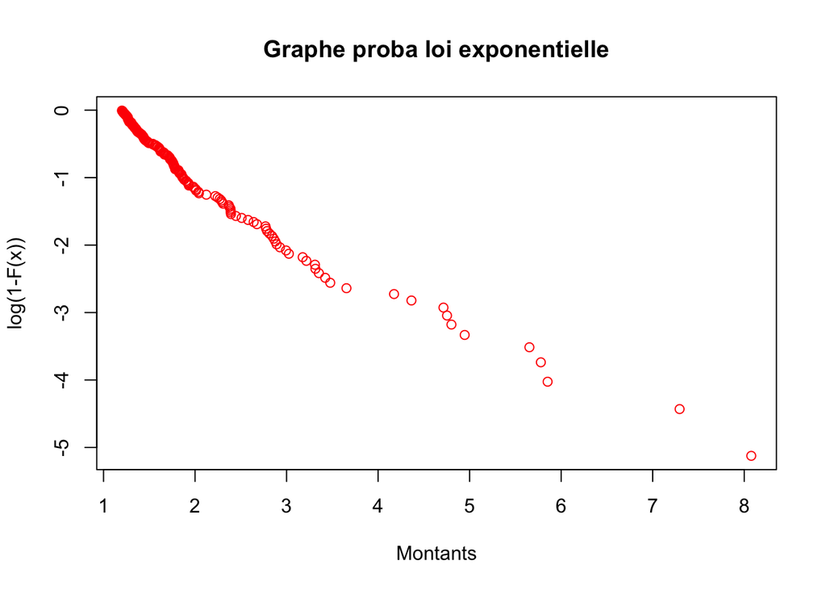

```r
#LOI EXP : graphe de proba pour loi exp
plot(s[1:(n-1)], log(1-seq(1:(n-1))/n),main='Graphe proba loi exponentielle',col='red', xlab="Montants", ylab="log(1-F(x))")
```

$\longrightarrow$ On remarque que les lois normale et exponentielle ne conviennent pas avec les données des sinistres (car les densités ne suivent pas la meme pente que l’histogramme et que les points des graphes de proba ne sont pas assez alignés)

### Question 2

- Tracer la fonction de répartition empirique pour ces données et calculer les principaux indicateurs statistiques. En déduire les caractéristiques essentielles de ces données. Quelle est la principale explication du fait que les modèles usuels de loi normale et exponentielle ne sont pas adaptés ?

#### Réponse :

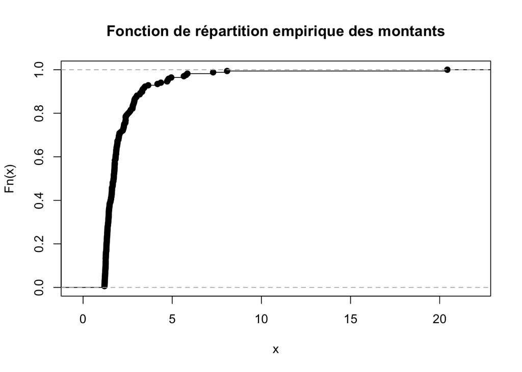

```r
plot(ecdf(s), main="Fonction de répartition empirique des montants")
```

Ses principaux indicateurs statistiques sont :

```r
summary(s)
```

```
##    Min. 1st Qu.  Median    Mean 3rd Qu.    Max.
##   1.201   1.361   1.720   2.168   2.322  20.430
```

```r
var(s)
```

```
## [1] 3.258359
```

### Question 3

- Calculer la fonction de répartition, l’espérance et la variance de X. Quelle condition doit vérifier $a$ pour que cette loi admette une espérance et une variance finies ? On admettra que cette condition est vérifiée.

#### Réponse :

$\begin{align} F_X(x) &= \int_{- \infty}^{x} f_X(t) \; dt \\ &= \int_{b}^{x} \frac{a.b^a}{t^{1+a}} \; dt \\ &= a.b^a \; \left[\frac{t^{-a}}{-a}\right]_b^x \\ &= 1 - \left(\frac{b}{x}\right)^a \end{align}$  
$\begin{align} \mathbb{E}[X] &= \int_{- \infty}^{+ \infty} f_X(t).t\; dt \\ &= a.b^a \left[\frac{t^{-a+1}}{-a+1}\right]^{+ \infty}_b \\ &= \frac{a.b}{a-1} \end{align}$  
Pour que X admette une espérance finie il faut que $-a+1 < 0 \Longleftrightarrow a > 1$  
$\begin{align} Var(X) &= \mathbb{E}[X²]-(\mathbb{E}[X])² \\ &= \frac{a.b²}{(a-2).(a-1)²} \end{align}$  
car :  
$\begin{align} \mathbb{E}[X²] &= \int_{- \infty}^{+ \infty} f_X(t).t²\; dt \quad \textit{, avec le théoreme de transfert}\\ &= ab^a[\dfrac{t^{-a+2}}{-a+2}]\\&=\frac{a.b²}{a-2} \end{align}$  
X admet une variance finie ssi $-a+2 < 0 \Longleftrightarrow a > 2$

On a donc :

$\large{\boxed{F_X(x) = 1 - \left(\frac{b}{x}\right)^a \\ \mathbb{E}[X] = \frac{a.b}{a-1} \\ Var(X) = \frac{a.b²}{(a-2).(a-1)²}}}$

### Question 4

- Déterminer l’expression d’un graphe de probabilités pour cette loi et en déduire des estimateurs graphiques $a_g$ et $b_g$ de $a$ et $b$.

#### Réponse :

Graphe de probabilités de forme : $h(F(X)) = \alpha(a,b).g(x)+\beta(a,b)$. On trace ensuite les points : $(g(x_i^*),h(\frac{i}{n}))$  
On a $F(x) = 1 - \left(\frac{b}{x}\right)^a \Rightarrow ln(1-F(x)) = -a.ln(x) + a.ln(b)$  
On identifie donc : $\begin{cases} h(x) = ln(1-x) \\ \alpha(a,b) \overset{pente}= -a \\ g(x) = ln(x) \\ \beta(a,b) \overset{ord \: ori}= a.ln(b) \end{cases}$  
On a donc : $a = -\alpha(a,b) \\ b = e^{\frac{\beta}{a}}$

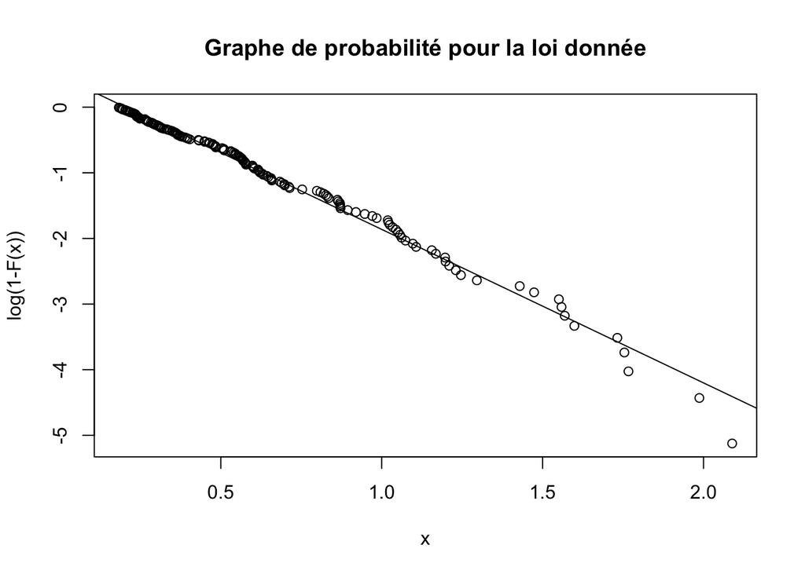

```r
#LOI Pa(a,b) : graphe de proba pour loi Pa(a,b)
plot(log(s[1:(n-1)]), log(1-seq(1:(n-1))/n), main="Graphe de probabilité pour la loi donnée", xlab="x", ylab="log(1-F(x))")

#estimation de a et b par le graphe de probabilités
reg <- lm(log(1-seq(1:(n-1))/n)~log(s[1:(n-1)]))
abline(reg)
```

```r
a <- -reg$coefficients[2]
b <- exp(reg$coefficients[1]/a)
print(paste("ag =", a))
```

```
## [1] "ag = 2.33944245774449"
```

```r
print(paste("bg =", b))
```

```
## [1] "bg = 1.22674230856402"
```

### Question 5

- Déterminer les estimateurs de $a$ et $b$ par la méthode des moments, $\tilde{a}_n$ et $\tilde{b}_n$.

#### Réponse :

$\begin{cases} \mathbb{E}[X] = \frac{a.b}{a-1} \\ Var(X) = \frac{a.b²}{(a-2).(a-1)²} \end{cases} \implies \begin{cases} b_n=\frac{a-1}{a}\overline{X_n} \\a_n(a_n-2)=\frac{\overline{X_n}²}{S_n} \end{cases}\implies \begin{cases}b_n=\frac{(a_n-1)}{a_n}\overline{X_n}\\a_n=1+\sqrt{1+\frac{\overline{X_n}²}{S_n}}\end{cases}$

On a donc :

$\large{\boxed{\tilde{a_n} = 1 + \sqrt{1+\frac{\overline{X_n}^2}{S_n}} \\ \tilde{b_n} = \frac{S_n}{\overline{X_n}}.(\tilde{a_n}-2).(\tilde{a_n}-1)}}$

### Question 6

- Déterminer les estimateurs de $a$ et $b$ par la méthode du maximum de vraissemblance, $\hat{a}_n$ et $\hat{a}_n$.

#### Réponse

$\begin{align*} L((a,b),(x_î))&=\prod\limits_{i=1}^{n}f_X(x_i)\\&=\prod\limits_{i=1}^{n}\dfrac{ab^a}{x_i^{1+a}}\mathbb{1}_{[b,+\infty[}(x_i) \end{align*}$  
$\begin{align*} L((a,b),(x_î))&=\prod\limits_{i=1}^{n}f_X(x_i)\\&=\prod\limits_{i=1}^{n}\dfrac{ab^a}{x_i^{1+a}}\mathbb{1}_{[b,+\infty[}(x_i) \end{align*}$  
Pour maximiser cette fonction par rapport à $b$ il faut choisir $b$ tel que $\forall x_i, x_i\in [b,+\infty[$ afin que le produit ne soit pas nulle. Ensuite on choisit le $b$ maximum qui vérifie cette condition pour maximer $b^a$.  
D’où $\boxed{\hat{b}_n=Min(x_i)}$  
Cherchons maintenant a qui maximise cette fonction. Pour cela nous allons appliquer $ln(u)$ (le produit ne s’annule pas grâce au choix de $b$) puis dériver par rapport à $a$.

$\begin{align*} ln(L((a,b),(x_î)))&=\sum\limits_{i=1}^{n}ln(\dfrac{ab^a}{x_i^{1+a}}\mathbb{1}_{[b,+\infty[}(x_i))\\&=nln(ab^a)\end{align*}$  
$\begin{align*}\implies ln(L((a,b),(x_î))) &= \sum\limits_{i=1}^nln(\dfrac{ab^a}{x^{1+a}})\mathbb{1}_{[b,+\infty[}(x_i)\\&=\sum\limits_{i=1}^nln(\dfrac{aMin(x_i)^a}{x^{1+a}})\mathbb{1}_{[Min(x_i),+\infty[}(x_i)\\&=\sum\limits_{i=1}^nln(\dfrac{aMin(x_i)^a}{x^{1+a}})\\&=n(ln(a)+aln(Min(x_i)))-(1+a)\sum\limits_{i=1}^{n} ln(x_i)\end{align*}$  
$\implies \dfrac{\partial ln(L((a,b),(x_î)))}{\partial a}=\dfrac{n}{a}+nln(Min(x_i))-\sum\limits_{i=1}^{n}ln(x_i)$  
S’annule pour $\boxed{\hat{a}_n=\dfrac{1}{\dfrac{1}{n}(\sum\limits_{i=1}^nln(x_i))-ln(b_n)}}$

### Question 7

- La loi $Pa(a,b)$ vous parait-elle un modèle plausible pour les montants de sinistres ? Si oui, calculer toutes les estimations de $a$ et $b$ pour ces données.

### Question 1

- Donner la loi de probabilité de $Y = ln{X \over b}$. En déduire comment simuler un échantillon de taille n de la loi $Pa(a, b)$.

#### Réponse

$\begin{align*} F_Y(y)&=P(Y\leq y)\\&=P(ln(\dfrac{X}{b})\leq y)\\&=P(X\leq e^yb)\\&=F_X(e^yb)\\\\&\boxed{F_Y(y)=1-\dfrac{1}{e^{ay}}}\end{align*}$  
On remarque que $Y \hookrightarrow Exp(a)$  
Pour simuler un échantillon de taille n de la loi $P_a(a,b)$:  
SOLUTION 1 :  
1) simuler une loi EXPONENTIELLE(a)  
2) puis appliquer $X=b.e^Y$  
SOLUTION 2 ( si on ne dispose pas d’un simulateur de loi exponentielle ) :  
1) $F_Y(y)=1-\dfrac{1}{e^{ay}} \implies F_Y^{-1}(y) = \dfrac{-ln(1-y)}{a} \ \forall y \in[0,1[$  
2) Générer un échantillon de taille n de la loi uniforme sur $[0,1[$ et appliquer $F_Y^{-1}(u)$  
3) Appliquer : $X=b.e^Y$

### Question 2a

- Pour un échantillon $x_1, ..., x_n$ de la loi $Pa(a, b)$, donner l’expression d’un intervalle de confiance de seuil $\alpha$ pour $a$.

#### Réponse

On cherche I un intevalle tel que $P(a\in I)=1-\alpha$. (1)  
On sait que $\sum\limits_{i=1}^{n}Y_i\hookrightarrow G(n,a)$  
Posons : $Z_n = \sum\limits_{i=1}^{n} Y_i$  
On a $Z_n \hookrightarrow G(n , \frac{1}{2}) = \chi_{2n}^2$

On a alors trouvé notre fonction pivotable pour la loi Y.  
Soit deux réels $c,d$ tels que $P(c \lt 2anZ_n \lt d)=1-\alpha$  
Or, $P(c\lt 2anZ_n\lt d) = F_{\chi_{2n}²}(d)- F_{\chi_{2n}²}(c)$  
On choisit $F_{\chi_{2n}²}(d)= 1-\dfrac{\alpha}{2}\\F_{\chi_{2n}²}(c)=\dfrac{\alpha}{2}$  
En appliquant la fonction inverse de $F_{\chi_{2n}²}$  
$\begin{cases} d=z_{2n,\dfrac{\alpha}{2}}\\c=z_{2n,1-\dfrac{\alpha}{2}}\end{cases}$  
Ainsi avec (1) on obtient : $P\biggl(\dfrac{z_{2n,1-\frac{\alpha}{2}}}{2\overline{Y}n} \lt a \lt \dfrac{z_{2n,\frac{\alpha}{2}}}{2\overline{Y}n}\biggl)$  
Donc : $I = \biggl[\dfrac{z_{2n,1-\frac{\alpha}{2}}}{2\overline{Y}n},\dfrac{z_{2n,\frac{\alpha}{2}}}{2\overline{Y}n}\biggl]$

### Question 2b

- Vérifier expérimentalement que, quand on simule un grand nombre $m$ d’échantillons de taille n de la loi $Pa(a, 2)$, alors une proportion approximativement égale à $1 - \alpha$ des intervalles de confiance de seuil $\alpha$ obtenus contient la vraie valeur du paramètre $a$. Prendre plusieurs valeurs de $a, m, n$ et $\alpha$ et commenter les résultats.

#### Réponse

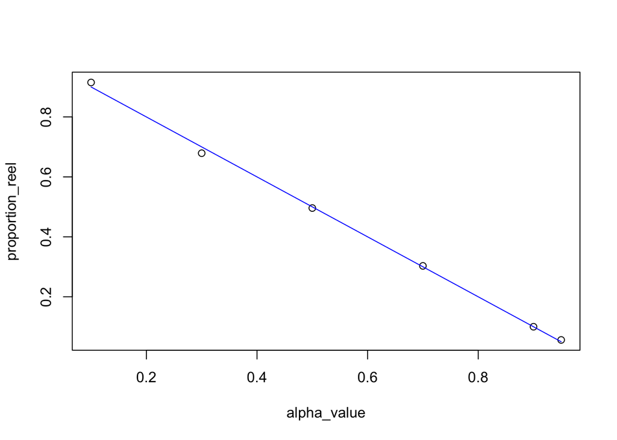

```r
a <- 3
b <- 2
alpha_value  <- c(0.1,0.3,0.5,0.7,0.9,0.95)
n <- 100 # taille de l'échantillon
m  <- 1000
proportion_reel <- c()
for (alpha in alpha_value){
  compteur <- 0
  for ( i in 1:m)
  {
    ech_Y <- rexp(n,rate = a)
    ech_X <- exp(ech_Y)*b
    z1 <- qchisq(alpha/2,2*n)
    z2 <- qchisq(1-alpha/2,2*n)
    I_inf <- z1/(2*n*mean(ech_Y))
    I_sup <- z2/(2*n*mean(ech_Y))
    if (I_inf <= a){
      if (a <= I_sup){
        compteur <- compteur+1
      }
    }
  }
  proportion_reel <- c(proportion_reel,compteur/m)
}
plot(alpha_value,proportion_reel)
lines(alpha_value, 1 - alpha_value, col = "blue")
```

On a ici en bleu la droite $1-\alpha$ et les points correspondent aux proportions de valeurs vrais qui tombe dans l’intervalle en fonction de $\alpha$. Les points sont assez proches et alignés avec la droite on peut donc conclure que0 *l’intervalle de confiance est fiable.*

### Question 3

- Comparer les différents estimateurs obtenus pour les paramètres $a$ et $b$ dans les questions 4, 5, et 6 de la première partie.

```r
n <-500 # taille de l'échantillon
m  <- 10
a_reg  <- c() ## estimateur graph proba
b_reg   <- c()
a_mv <- c() ## EMV
b_mv <- c()
a_n <- c()  ## EMM
b_n <- c()
for (i in 1:m){
  a  <- 2
  b   <- 1
  ech_Y <- rexp(n,rate = a)
  ech_X <- exp(ech_Y)*b
  a_n <- c(a_n,1+sqrt(1+((mean(ech_X)^2)/var(ech_X))))
  b_n  <- c(b_n,(((1+sqrt(1+((mean(ech_X)^2)/var(ech_X))))-1)/(1+sqrt(1+((mean(ech_X)^2)/var(ech_X)))))*mean(ech_X))
  b_mv <-c(b_mv,min(ech_X))
  a_mv <-c(a_mv,1/((sum(log(ech_X))/n)-log(min(ech_X))))
}



## estimateur des moments de a
print(a_n)
```

```
##  [1] 2.562646 2.567520 2.485894 2.630426 2.370840 2.412607 2.204919 2.221838
##  [9] 2.434778 2.234450
```

```r
## estimateur des moments de b
print(b_n)
```

```
##  [1] 1.185924 1.181321 1.125596 1.173744 1.214172 1.148792 1.096312 1.195328
##  [9] 1.187601 1.191322
```

```r
### EMV de b
print(b_mv)
```

```
##  [1] 1.000305 1.000678 1.001399 1.000613 1.000250 1.002488 1.000061 1.000400
##  [9] 1.000957 1.000264
```

```r
### EMV de a
print(a_mv)
```

```
##  [1] 1.994454 2.020155 2.085543 2.012928 1.854024 2.053414 2.035447 1.910352
##  [9] 1.986008 1.893912
```

```r
### calcul du biais

biais_a_n <- mean(a_n)-a
biais_b_n <- mean(b_n)-b
biais_a_mv <- mean(a_mv)-a
biais_b_mv <- mean(b_mv)-b

print(biais_a_n)
```

```
## [1] 0.4125918
```

```r
print(biais_b_n)
```

```
## [1] 0.1700112
```

```r
print(biais_a_mv)
```

```
## [1] -0.01537643
```

```r
print(biais_b_mv)
```

```
## [1] 0.0007415601
```

```r
### calcul des erreurs quadratiques

eqm_a_n <- mean((a_n-a)^2)
eqm_b_n <- mean((b_n-b)^2)
eqm_a_mv <- mean((a_mv-a)^2)
eqm_b_mv <- mean((b_mv-b)^2)


print(eqm_a_n)
```

```
## [1] 0.1915149
```

```r
print(eqm_b_n)
```

```
## [1] 0.03006423
```

```r
print(eqm_a_mv)
```

```
## [1] 0.005282736
```

```r
print(eqm_b_mv)
```

```
## [1] 1.028728e-06
```

L’erreur quadratique moyenne est plus faible pour l’estimateur de maximum de vraissemblance.  
*CCL : EMV > EMM*

### Question 4

- Vérifier la convergence en probabilité de $\tilde{a}_n$ et $\bar{a}_n$.
- Quel estimateur converge le plus vite ?

### Réponse

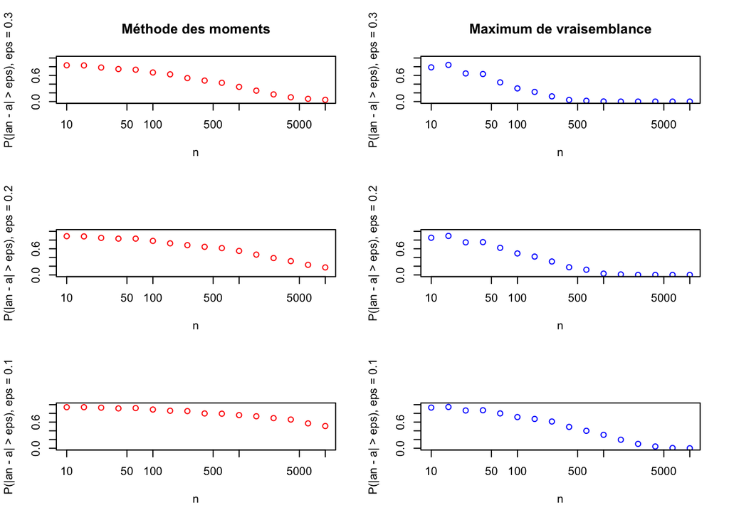

```r
a <- 3
b <- 2
n_value <- 10**seq(from=1, to=4, by=0.2)
m <- 1000

eps1 <- 0.3
proportion_reel_moment1 <- c()
proportion_reel_vraisemblance1 <- c()
eps2 <- 0.2
proportion_reel_moment2 <- c()
proportion_reel_vraisemblance2 <- c()
eps3 <- 0.1
proportion_reel_moment3 <- c()
proportion_reel_vraisemblance3 <- c()

for (n in n_value){
  compteur_moment1 <- 0
  compteur_vraisemblance1 <- 0
  compteur_moment2 <- 0
  compteur_vraisemblance2 <- 0
  compteur_moment3 <- 0
  compteur_vraisemblance3 <- 0

  for (i in 1:m){
    ech_Y <- rexp(n,rate = a)
    ech_X <- exp(ech_Y)*b
    an_moment <- 1 + sqrt(1+(mean(ech_X)^2)/var(ech_X))
    bn_vraisemblance <- min(ech_X)
    an_vraisemblance <- n/(sum(log(ech_X)) - n*log(bn_vraisemblance))

    if (abs(an_moment - a) <= eps1){
      compteur_moment1 <- compteur_moment1+1
    }
    if (abs(an_moment - a) <= eps2){
      compteur_moment2 <- compteur_moment2+1
    }
    if (abs(an_moment - a) <= eps3){
      compteur_moment3 <- compteur_moment3+1
    }
    if (abs(an_vraisemblance - a) <= eps1){
      compteur_vraisemblance1 <- compteur_vraisemblance1+1
    }
    if (abs(an_vraisemblance - a) <= eps2){
      compteur_vraisemblance2 <- compteur_vraisemblance2+1
    }
    if (abs(an_vraisemblance - a) <= eps3){
      compteur_vraisemblance3 <- compteur_vraisemblance3+1
    }
  }

  proportion_reel_moment1 <- c(proportion_reel_moment1,compteur_moment1/m)
  proportion_reel_vraisemblance1 <- c(proportion_reel_vraisemblance1, compteur_vraisemblance1/m)
  proportion_reel_moment2 <- c(proportion_reel_moment2,compteur_moment2/m)
  proportion_reel_vraisemblance2 <- c(proportion_reel_vraisemblance2, compteur_vraisemblance2/m)
  proportion_reel_moment3 <- c(proportion_reel_moment3,compteur_moment3/m)
  proportion_reel_vraisemblance3 <- c(proportion_reel_vraisemblance3, compteur_vraisemblance3/m)

}

par(mfrow=c(3,2))
plot(n_value, 1 - proportion_reel_moment1, ylim=c(0,1), log="x", col = "red", main="Méthode des moments",  xlab="n", ylab="P(|an - a| > eps), eps = 0.3")
plot(n_value, 1 - proportion_reel_vraisemblance1, ylim=c(0,1), log="x", col = "blue", main="Maximum de vraisemblance", xlab="n", ylab="P(|an - a| > eps), eps = 0.3")
plot(n_value, 1 - proportion_reel_moment2, ylim=c(0,1), log="x", col = "red", xlab="n", ylab="P(|an - a| > eps), eps = 0.2")
plot(n_value, 1 - proportion_reel_vraisemblance2, ylim=c(0,1), log="x", col = "blue", xlab="n", ylab="P(|an - a| > eps), eps = 0.2")
plot(n_value, 1 - proportion_reel_moment3, ylim=c(0,1), log="x", col = "red", xlab="n", ylab="P(|an - a| > eps), eps = 0.1")
plot(n_value, 1 - proportion_reel_vraisemblance3, ylim=c(0,1), log="x", col = "blue", xlab="n", ylab="P(|an - a| > eps), eps = 0.1")
```

On remarque que la méthode du maximum de vraisemblance permet une convergence plus rapide que la méthode des moments.

### Question 5

- Sur les échantillons de $m$ estimations de $\tilde{a}_n$ et $\bar{a}_n$, tracer un histogramme et un graphe de probabilités pour la loi normale. Faire varier $n$ en partant de $n = 5$.

#### Réponse

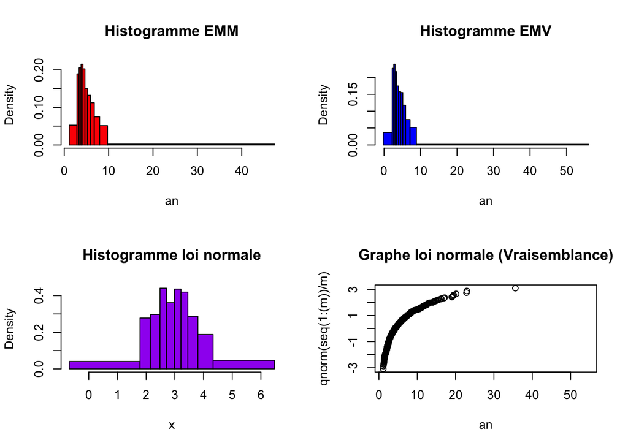

```
## [1] "Pour la méthode du maximum de vraisemblance, pour n = 5"
## [1] "Moyenne empirique = 5.10836004609141"
## [1] "Variance empirique = 12.5483759410896"
```

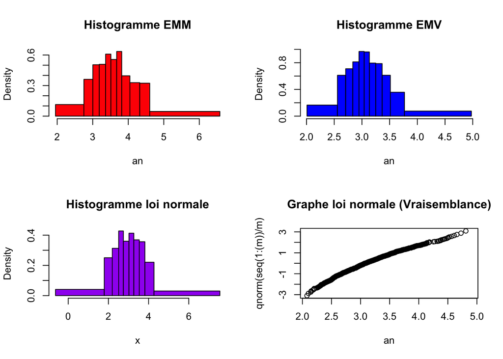

```
## [1] "Pour la méthode du maximum de vraisemblance, pour n = 50"
## [1] "Moyenne empirique = 3.13112166212287"
## [1] "Variance empirique = 0.211075303826752"
```

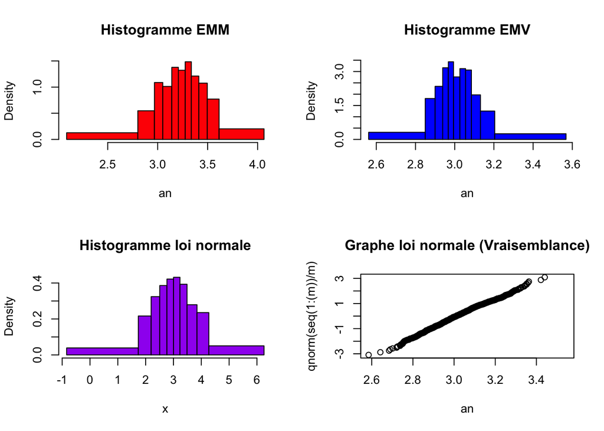

```
## [1] "Pour la méthode du maximum de vraisemblance, pour n = 500"
## [1] "Moyenne empirique = 3.01677823050551"
## [1] "Variance empirique = 0.0173190878093995"
```

```r
a <- 3
b <- 2
m <- 1000
n_value = c(5, 50, 500)

for (n in n_value){
  liste_an_moment = c()
  liste_an_vraisemblance = c()
  for (i in 1:m){
    ech_Y <- rexp(n,rate = a)
    ech_X <- exp(ech_Y)*b
    an_moment <- 1 + sqrt(1+(mean(ech_X)^2)/var(ech_X))
    bn_vraisemblance <- min(ech_X)
    an_vraisemblance <- n/(sum(log(ech_X)) - n*log(bn_vraisemblance))
    liste_an_moment = c(liste_an_moment, an_moment)
    liste_an_vraisemblance = c(liste_an_vraisemblance, an_vraisemblance)
  }
  par(mfrow=c(2,2))

  liste_an_moment = sort(liste_an_moment)
  min_moment = min(liste_an_moment)
  max_moment = max(liste_an_moment)
  a0 = min_moment - 0.025 * (max_moment - min_moment)
  ak = max_moment + 0.025 * (max_moment - min_moment)
  k = round(1 + log(m, base = 2))
  bornes <- c(a0, quantile(liste_an_moment, seq(1, k-1) / k), ak)
  hist(liste_an_moment, breaks=bornes, main="Histogramme EMM", col="red", xlab="an")

  liste_an_vraisemblance = sort(liste_an_vraisemblance)
  min_vraisemblance = min(liste_an_vraisemblance)
  max_vraisemblance = max(liste_an_vraisemblance)
  a0 = min_vraisemblance - 0.025 * (max_vraisemblance - min_vraisemblance)
  ak = max_vraisemblance + 0.025 * (max_vraisemblance - min_vraisemblance)
  k = round(1 + log(m, base = 2))
  bornes <- c(a0, quantile(liste_an_vraisemblance, seq(1, k-1) / k), ak)
  hist(liste_an_vraisemblance, breaks=bornes, main="Histogramme EMV", col='blue', xlab="an")

  x <- sort(rnorm(m, a, 1))
  mini = min(x)
  maxi = max(x)
  a0 = mini - 0.025 * (maxi - mini)
  ak = maxi + 0.025 * (maxi - mini)
  k = round(1 + log(500, base = 2))
  bornes <- c(a0, quantile(x, seq(1, k-1) / k), ak)
  hist(x, breaks=bornes, main="Histogramme loi normale", col="purple")

  plot(liste_an_vraisemblance, qnorm(seq(1:(m))/m),main='Graphe loi normale (Vraisemblance)', xlab="an")

  print(paste("Pour la méthode du maximum de vraisemblance, pour n =", n))
  print(paste("Moyenne empirique =", mean(liste_an_vraisemblance)))
  print(paste("Variance empirique =", var(liste_an_vraisemblance)))
}
```